# Econometrics Project: Analysis of Boston Housing Data

Yifei Ding

2024-05-14

## Introduction

This project conducts an econometric analysis of the Boston Housing dataset, available in the `MASS` library. This dataset contains data on various aspects of the housing market in the Boston area, and this analysis aims to identify factors influencing house prices using multiple linear regression techniques.

## Data Section

The Boston Housing dataset comprises 506 observations on 14 variables. The data is sourced from the `MASS` library which is a standard R package.

```r
data(Boston, package = "MASS")
summary(Boston)
```

```
##       crim                zn             indus            chas
##  Min.   : 0.00632   Min.   :  0.00   Min.   : 0.46   Min.   :0.00000
##  1st Qu.: 0.08205   1st Qu.:  0.00   1st Qu.: 5.19   1st Qu.:0.00000
##  Median : 0.25651   Median :  0.00   Median : 9.69   Median :0.00000
##  Mean   : 3.61352   Mean   : 11.36   Mean   :11.14   Mean   :0.06917
##  3rd Qu.: 3.67708   3rd Qu.: 12.50   3rd Qu.:18.10   3rd Qu.:0.00000
##  Max.   :88.97620   Max.   :100.00   Max.   :27.74   Max.   :1.00000
##       nox               rm             age              dis
##  Min.   :0.3850   Min.   :3.561   Min.   :  2.90   Min.   : 1.130
##  1st Qu.:0.4490   1st Qu.:5.886   1st Qu.: 45.02   1st Qu.: 2.100
##  Median :0.5380   Median :6.208   Median : 77.50   Median : 3.207
##  Mean   :0.5547   Mean   :6.285   Mean   : 68.57   Mean   : 3.795
##  3rd Qu.:0.6240   3rd Qu.:6.623   3rd Qu.: 94.08   3rd Qu.: 5.188
##  Max.   :0.8710   Max.   :8.780   Max.   :100.00   Max.   :12.127
##       rad              tax           ptratio          black
##  Min.   : 1.000   Min.   :187.0   Min.   :12.60   Min.   :  0.32
##  1st Qu.: 4.000   1st Qu.:279.0   1st Qu.:17.40   1st Qu.:375.38
##  Median : 5.000   Median :330.0   Median :19.05   Median :391.44
##  Mean   : 9.549   Mean   :408.2   Mean   :18.46   Mean   :356.67
##  3rd Qu.:24.000   3rd Qu.:666.0   3rd Qu.:20.20   3rd Qu.:396.23
##  Max.   :24.000   Max.   :711.0   Max.   :22.00   Max.   :396.90
##      lstat            medv
##  Min.   : 1.73   Min.   : 5.00
##  1st Qu.: 6.95   1st Qu.:17.02
##  Median :11.36   Median :21.20
##  Mean   :12.65   Mean   :22.53
##  3rd Qu.:16.95   3rd Qu.:25.00
##  Max.   :37.97   Max.   :50.00
```

## Descriptive Statistics Table

The table below presents descriptive statistics for the Boston Housing dataset, providing a preliminary understanding of variable distributions.

```r
Boston %>%
  summary() %>%
  kable() %>%
  kable_styling(bootstrap_options = c("striped", "hover"))
```

|  | crim | zn | indus | chas | nox | rm | age | dis | rad | tax | ptratio | black | lstat | medv |
| --- | --- | --- | --- | --- | --- | --- | --- | --- | --- | --- | --- | --- | --- | --- |
|  | Min. : 0.00632 | Min. : 0.00 | Min. : 0.46 | Min. :0.00000 | Min. :0.3850 | Min. :3.561 | Min. : 2.90 | Min. : 1.130 | Min. : 1.000 | Min. :187.0 | Min. :12.60 | Min. : 0.32 | Min. : 1.73 | Min. : 5.00 |
|  | 1st Qu.: 0.08205 | 1st Qu.: 0.00 | 1st Qu.: 5.19 | 1st Qu.:0.00000 | 1st Qu.:0.4490 | 1st Qu.:5.886 | 1st Qu.: 45.02 | 1st Qu.: 2.100 | 1st Qu.: 4.000 | 1st Qu.:279.0 | 1st Qu.:17.40 | 1st Qu.:375.38 | 1st Qu.: 6.95 | 1st Qu.:17.02 |
|  | Median : 0.25651 | Median : 0.00 | Median : 9.69 | Median :0.00000 | Median :0.5380 | Median :6.208 | Median : 77.50 | Median : 3.207 | Median : 5.000 | Median :330.0 | Median :19.05 | Median :391.44 | Median :11.36 | Median :21.20 |
|  | Mean : 3.61352 | Mean : 11.36 | Mean :11.14 | Mean :0.06917 | Mean :0.5547 | Mean :6.285 | Mean : 68.57 | Mean : 3.795 | Mean : 9.549 | Mean :408.2 | Mean :18.46 | Mean :356.67 | Mean :12.65 | Mean :22.53 |
|  | 3rd Qu.: 3.67708 | 3rd Qu.: 12.50 | 3rd Qu.:18.10 | 3rd Qu.:0.00000 | 3rd Qu.:0.6240 | 3rd Qu.:6.623 | 3rd Qu.: 94.08 | 3rd Qu.: 5.188 | 3rd Qu.:24.000 | 3rd Qu.:666.0 | 3rd Qu.:20.20 | 3rd Qu.:396.23 | 3rd Qu.:16.95 | 3rd Qu.:25.00 |
|  | Max. :88.97620 | Max. :100.00 | Max. :27.74 | Max. :1.00000 | Max. :0.8710 | Max. :8.780 | Max. :100.00 | Max. :12.127 | Max. :24.000 | Max. :711.0 | Max. :22.00 | Max. :396.90 | Max. :37.97 | Max. :50.00 |

## Model Specification

We specify a multiple linear regression model considering the median value of owner-occupied homes (`medv`) as the dependent variable and the following as predictors: - `crim`: per capita crime rate by town - `zn`: proportion of residential land zoned for lots over 25,000 sq.ft. - `rm`: average number of rooms per dwelling

```r
model_formula <- medv ~ crim + zn + rm
```

## Empirical Results

The regression model is estimated below. We also output a summary to view detailed regression output including coefficients, residuals, and other diagnostics.

```r
model <- lm(model_formula, data = Boston)
summary(model)
```

```
##
## Call:
## lm(formula = model_formula, data = Boston)
##
## Residuals:
##     Min      1Q  Median      3Q     Max
## -19.892  -3.209  -0.409   2.489  38.769
##
## Coefficients:
##              Estimate Std. Error t value Pr(>|t|)
## (Intercept) -26.97158    2.61490  -10.31  < 2e-16 ***
## crim         -0.24633    0.03293   -7.48 3.36e-13 ***
## zn            0.04940    0.01247    3.96 8.57e-05 ***
## rm            7.92937    0.41575   19.07  < 2e-16 ***
## ---
## Signif. codes:  0 '***' 0.001 '**' 0.01 '*' 0.05 '.' 0.1 ' ' 1
##
## Residual standard error: 6.148 on 502 degrees of freedom
## Multiple R-squared:  0.5558, Adjusted R-squared:  0.5532
## F-statistic: 209.4 on 3 and 502 DF,  p-value: < 2.2e-16
```

## Presentation of Regression Results

We present the regression results in a formatted table for clearer interpretation.

```
##  Hlavac, Marek (2022). stargazer: Well-Formatted Regression and Summary Statistics Tables.
```

```
##  R package version 5.2.3. https://CRAN.R-project.org/package=stargazer
```

**Regression Results**

|  | *Dependent variable:* |
| --- | --- |
|  | medv |
| crim | -0.246*** (0.033) |
| zn | 0.049*** (0.012) |
| rm | 7.929*** (0.416) |
| Constant | -26.972*** (2.615) |
| Observations | 506 |
| R<sup>2</sup> | 0.556 |
| Adjusted R<sup>2</sup> | 0.553 |
| Residual Std. Error | 6.148 (df = 502) |
| F Statistic | 209.405*** (df = 3; 502) |
| *Note:* | p<0.1; p<0.05; p<0.01 |

## Interpretation of the Estimated Coefficients

- **crim**: The negative coefficient suggests that higher crime rates are associated with lower home values.
- **zn**: This positive coefficient indicates that larger zoning areas positively impact home values.
- **rm**: As expected, a greater number of rooms correlate with higher home values, reflecting that larger homes command higher prices.

## Discussion of the Assumptions of Multiple Linear Regression Analysis

We check the key assumptions of multiple linear regression, including linearity, homoscedasticity, normality of errors, and absence of multicollinearity.

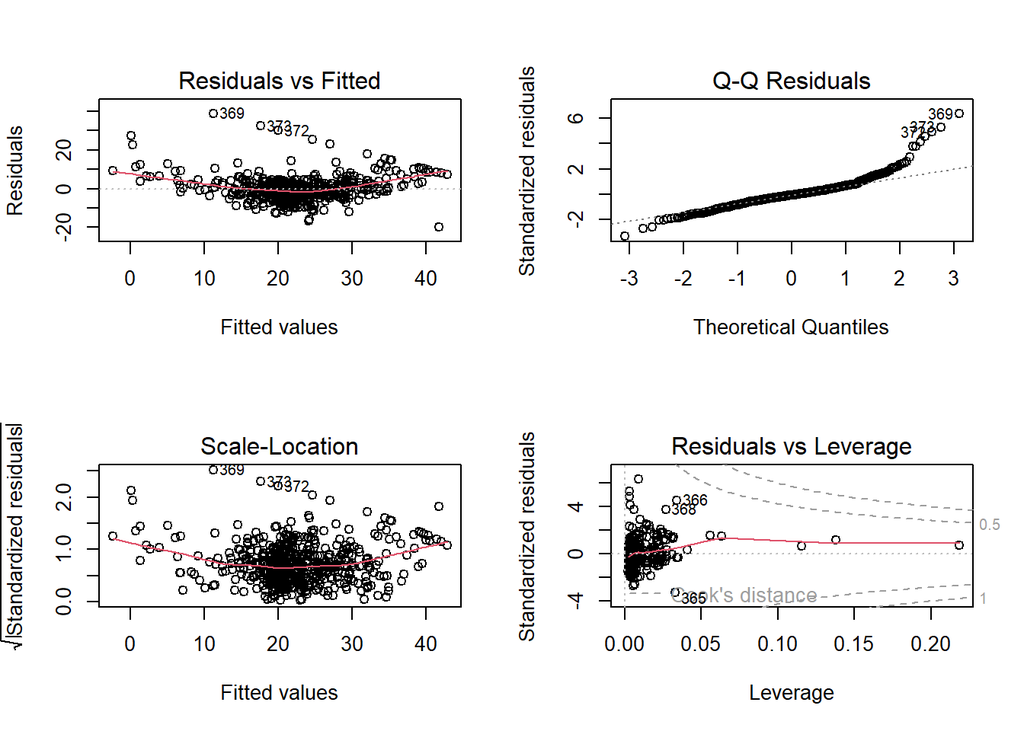

```r
par(mfrow=c(2,2))
plot(model)
```

### 1. Residuals vs Fitted Plot

#### What it Shows:

This plot is used to assess the assumption of linearity and homoscedasticity in your data.

Linearity: The residuals should scatter randomly around the horizontal line at zero without any systematic patterns.

Homoscedasticity: The spread of residuals should be consistent across all levels of fitted values.

#### Observations:

However, there seems to be a slight pattern where residuals are not evenly spread across the range of fitted values, hinting at potential heteroscedasticity.

### 2. Normal Q-Q Plot

#### What it Shows:

This plot checks if the residuals are normally distributed—an assumption underlying the inference techniques (like t-tests) used in regression analysis.

#### Observations:

The points in this plot largely follow the theoretical line, suggesting that the residuals are approximately normally distributed.

Some deviations at the ends of the plot suggest the presence of outliers or heavy tails in the distribution of residuals.

### 3. Scale-Location Plot

#### What it Shows:

This plot is another way to check for homoscedasticity, showing if residuals are spread equally along the ranges of predictors.

#### Observations:

The plot reveals that the spread of residuals is not uniform across the range of fitted values, indicating potential issues with homoscedasticity.

This uneven spread suggests that the variance of residuals is not constant, which can affect the reliability of standard errors and confidence intervals.

### 4. Residuals vs Leverage Plot

#### What it Shows:

This plot helps identify influential observations that might unduly influence the regression line. It combines information on both residuals and leverage.

#### Observations:

Most data points have low leverage except for a few, which is typical in datasets.

There are no points that combine both high leverage and large residuals, which suggests there are no particularly influential outliers significantly impacting the model fit.

### Recommendations Based on Observations:

Investigate Potential Heteroscedasticity: Consider transformations of the dependent variable or independent variables, such as logarithmic or square root transformations, to stabilize the variance across the data.

Address Non-normality: Although not severe, consider robust regression methods if outliers or non-normality are concerns, especially if the analysis becomes more sensitive to these assumptions.

Continue Monitoring Leverage Points: While no points are immediately problematic, it’s good practice to keep an eye on observations with higher leverage to ensure they do not affect conclusions if the model changes.

### Additional Checks:

Multicollinearity: We should examine if predictor variables are highly correlated, which can affect the model estimation.

```r
# Assuming the car package is installed
library(car)
vif(model)
```

```
##     crim       zn       rm
## 1.072261 1.130787 1.140149
```

### Independence of Errors: This assumption is crucial for hypothesis testing within regression models.

```r
library(lmtest)
dwtest(model)
```

```
##
##  Durbin-Watson test
##
## data:  model
## DW = 0.78978, p-value < 2.2e-16
## alternative hypothesis: true autocorrelation is greater than 0
```

## Conclusion

This analysis of the Boston Housing dataset utilized multiple linear regression to understand the impact of crime rates, zoning, and room numbers on housing prices. The results suggest significant effects of these variables on home values, with directions as hypothesized. Future studies could explore more complex models and additional variables such as accessibility to radial highways and pupil-teacher ratios by town.